# Penguins assignment

2022-12-05

## Question 04

### Preparing packages and data

Packages:

Raw data:

| X | studyName | Sample.Number | Species | Region | Island | Stage | Individual.ID | Clutch.Completion | Date.Egg | Culmen.Length..mm. | Culmen.Depth..mm. | Flipper.Length..mm. | Body.Mass..g. | Sex | Delta.15.N..o.oo. | Delta.13.C..o.oo. | Comments |
| --- | --- | --- | --- | --- | --- | --- | --- | --- | --- | --- | --- | --- | --- | --- | --- | --- | --- |
| 1 | PAL0708 | 1 | Adelie Penguin (Pygoscelis adeliae) | Anvers | Torgersen | Adult, 1 Egg Stage | N1A1 | Yes | 2007-11-11 | 39.1 | 18.7 | 181 | 3750 | MALE | NA | NA | Not enough blood for isotopes. |
| 2 | PAL0708 | 2 | Adelie Penguin (Pygoscelis adeliae) | Anvers | Torgersen | Adult, 1 Egg Stage | N1A2 | Yes | 2007-11-11 | 39.5 | 17.4 | 186 | 3800 | FEMALE | 8.94956 | -24.69454 | NA |
| 3 | PAL0708 | 3 | Adelie Penguin (Pygoscelis adeliae) | Anvers | Torgersen | Adult, 1 Egg Stage | N2A1 | Yes | 2007-11-16 | 40.3 | 18.0 | 195 | 3250 | FEMALE | 8.36821 | -25.33302 | NA |
| 4 | PAL0708 | 4 | Adelie Penguin (Pygoscelis adeliae) | Anvers | Torgersen | Adult, 1 Egg Stage | N2A2 | Yes | 2007-11-16 | NA | NA | NA | NA | NA | NA | NA | Adult not sampled. |
| 5 | PAL0708 | 5 | Adelie Penguin (Pygoscelis adeliae) | Anvers | Torgersen | Adult, 1 Egg Stage | N3A1 | Yes | 2007-11-16 | 36.7 | 19.3 | 193 | 3450 | FEMALE | 8.76651 | -25.32426 | NA |
| 6 | PAL0708 | 6 | Adelie Penguin (Pygoscelis adeliae) | Anvers | Torgersen | Adult, 1 Egg Stage | N3A2 | Yes | 2007-11-16 | 39.3 | 20.6 | 190 | 3650 | MALE | 8.66496 | -25.29805 | NA |

Clean data:

| x | study_name | sample_number | species | region | island | stage | individual_id | clutch_completion | date_egg | culmen_length_mm | culmen_depth_mm | flipper_length_mm | body_mass_g | sex |
| --- | --- | --- | --- | --- | --- | --- | --- | --- | --- | --- | --- | --- | --- | --- |
| 1 | PAL0708 | 1 | Adelie Penguin (Pygoscelis adeliae) | Anvers | Torgersen | Adult, 1 Egg Stage | N1A1 | Yes | 2007-11-11 | 39.1 | 18.7 | 181 | 3750 | MALE |
| 2 | PAL0708 | 2 | Adelie Penguin (Pygoscelis adeliae) | Anvers | Torgersen | Adult, 1 Egg Stage | N1A2 | Yes | 2007-11-11 | 39.5 | 17.4 | 186 | 3800 | FEMALE |
| 3 | PAL0708 | 3 | Adelie Penguin (Pygoscelis adeliae) | Anvers | Torgersen | Adult, 1 Egg Stage | N2A1 | Yes | 2007-11-16 | 40.3 | 18.0 | 195 | 3250 | FEMALE |
| 4 | PAL0708 | 4 | Adelie Penguin (Pygoscelis adeliae) | Anvers | Torgersen | Adult, 1 Egg Stage | N2A2 | Yes | 2007-11-16 | NA | NA | NA | NA | NA |
| 5 | PAL0708 | 5 | Adelie Penguin (Pygoscelis adeliae) | Anvers | Torgersen | Adult, 1 Egg Stage | N3A1 | Yes | 2007-11-16 | 36.7 | 19.3 | 193 | 3450 | FEMALE |
| 6 | PAL0708 | 6 | Adelie Penguin (Pygoscelis adeliae) | Anvers | Torgersen | Adult, 1 Egg Stage | N3A2 | Yes | 2007-11-16 | 39.3 | 20.6 | 190 | 3650 | MALE |

### Analysis of covariance (ANCOVA)

**Question:** Is the relationship between penguin culmen **length** -(response)- and culmen **depth** -(covariate)- significantly different between different **species**?

**Null Hypotheses (H<sub>0</sub>):**

1. The means between the species are not significantly different from each other.

2. The slopes of the regression lines between culmen **length** and culmen **depth** are not significantly different to 0.

3a. There is no relationship between penguin **species** and penguin culmen **length**.

3b. There is no relationship between penguin **species** and penguin culmen **depth**.

**Assumptions:**

1. Observations are independent, each subject belongs to one species only.

2. Distribution of data is approximately normally distributed.

3. The variance for the three species are approximately equal.

4. There are no significant outliers.

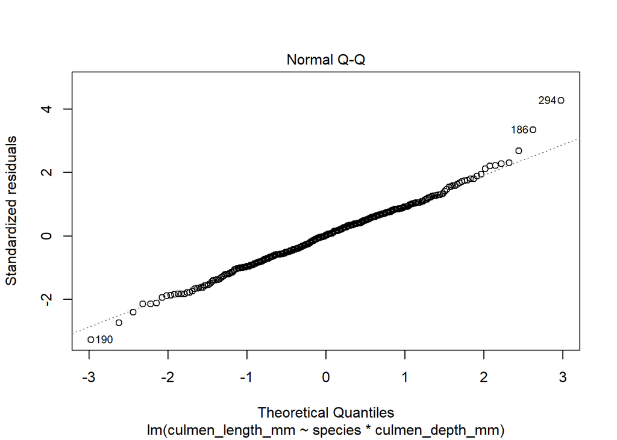

Although there are a some outliers on either end of the Q-Q plot. The points all fall approximately along the reference line, thus the data does not provide strong enough evidence that the data violates the approximate normality assumption.

#### Histogram:

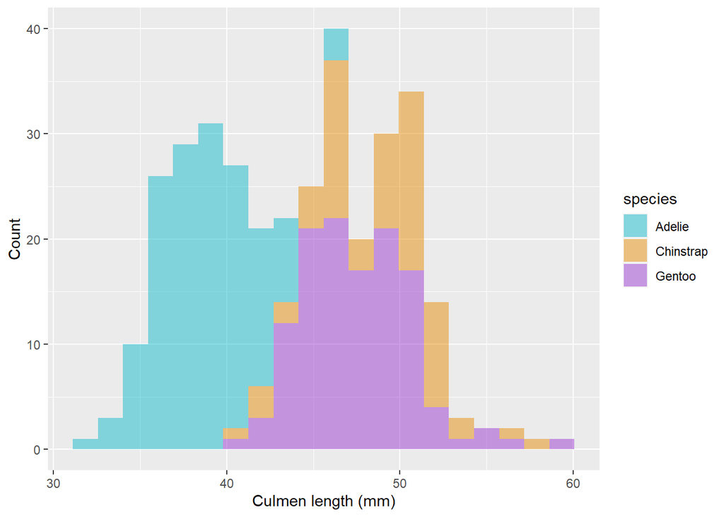

```
## # A tibble: 1 × 17
##   species          x study…¹ sampl…² region island stage indiv…³ clutc…⁴ date_…⁵
##   <chr>        <int> <chr>     <int> <chr>  <chr>  <chr> <chr>   <chr>   <chr>
## 1 Gentoo peng…   186 PAL0708      34 Anvers Biscoe Adul… N56A2   Yes     2007-1…
## # … with 7 more variables: culmen_length_mm <dbl>, culmen_depth_mm <dbl>,
## #   flipper_length_mm <int>, body_mass_g <int>, sex <chr>, is.outlier <lgl>,
## #   is.extreme <lgl>, and abbreviated variable names ¹study_name,
## #   ²sample_number, ³individual_id, ⁴clutch_completion, ⁵date_egg
```

There is only one extreme outlier so the overall result will not be substantially affected.

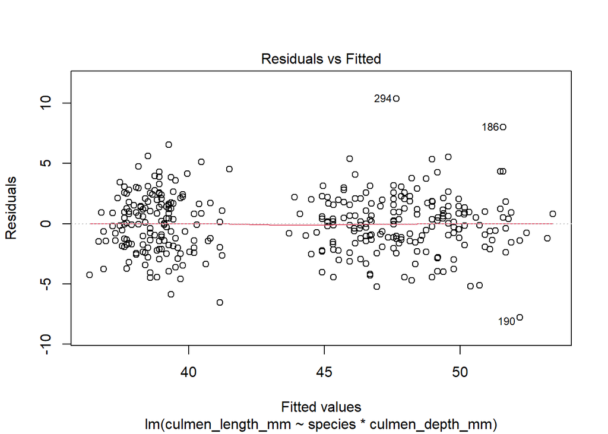

While there are some outliers, there is almost no deviation from the reference line. There is no significant relationship between residuals and fitted values, thus there is no evidence that strongly suggests the homogeneity of variances assumption has been violated.

```
## Call:
##    aov(formula = culmen_length_mm ~ species, data = penguins_clean)
##
## Terms:
##                  species Residuals
## Sum of Squares  7194.317  2969.888
## Deg. of Freedom        2       339
##
## Residual standard error: 2.959853
## Estimated effects may be unbalanced
## 2 observations deleted due to missingness
```

```
##              Df Sum Sq Mean Sq F value Pr(>F)
## species       2   7194    3597   410.6 <2e-16 ***
## Residuals   339   2970       9
## ---
## Signif. codes:  0 '***' 0.001 '**' 0.01 '*' 0.05 '.' 0.1 ' ' 1
## 2 observations deleted due to missingness
```

The F-value obtained is 410.6, which is significantly larger than 1. Thus, there is significant evidence to believe that the variation among species means is not likely due to chance.

### Data Visualisation:

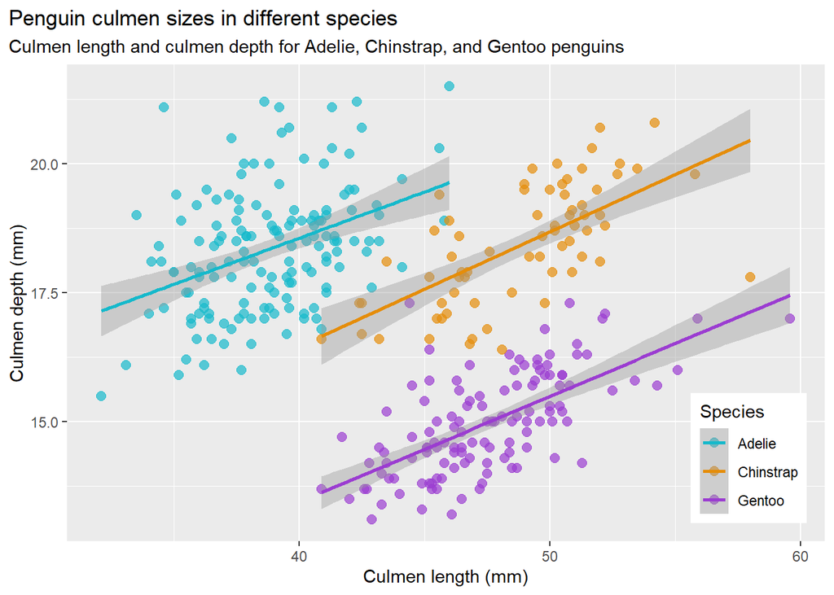

#### Saving data visualisation: